# What Traits Lead to a Successful Date?

### An Analysis on Speed Dating Success

### Created by *Owen Maschal*

The intention of this project is discover was aspects of a person lead to a more successful date.

We will be using a multitude of Python Packages in this tutorial.

- [Pandas](https://pandas.pydata.org/): Used to handle our data and data analysis.
- [Numpy](https://docs.scipy.org/doc/numpy-1.15.1/reference/): Used for linear algebra operations.
- [Seaborn](https://seaborn.pydata.org/): Used to make pretty graphs and charts.
- [MatPlotLib](https://matplotlib.org/): Extended by Seaborn. Used to create basic graphs and charts in Python.
- [SciKit-Learn](https://scikit-learn.org/stable/): Machine Learning and Data Analysis library

```python
import pandas as pd
import numpy as np
import matplotlib.pyplot as plt
from matplotlib.pyplot import figure
import seaborn as sns
import math
from sklearn import linear_model
from sklearn.metrics import mean_squared_error, r2_score
from sklearn.model_selection import train_test_split, KFold
from sklearn.neighbors import KNeighborsClassifier
```

```python
# Display all charts/graphs inline
%matplotlib inline

sns.set_style("darkgrid") # Set the Seaborn style
pd.set_option('display.max_columns', None) # show all cols of pandas table
#pd.set_option('display.max_rows', None) # show all cols of pandas table
```

## Data Source

This dataset was compiled by Columbia Business School professors Ray Fisman and Sheena Iyengar for their paper *Gender Differences in Mate Selection: Evidence From a Speed Dating Experiment*. The data was gathered from a series of speed dating experiments from 2002-2004.

At each event each participant would be given a 4-minute first date with each of the participants of the other gender. At the end of each date each participant was asked if they would like to see their date again and were asked to rate them on 6 traits: Attractiveness, Sincerity, Intelligence, Fun, Ambition, and Shared Interests.

In addition, the dataset includes responses from multiple surveys where the participants were asked various questions on topics including demographics, dating habits, self-perception across key attributes, beliefs on what others find valuable in a mate, and lifestyle information. Three surveys were completed in total: one at the time of event registration, one the day after the event, and one 3-4 weeks after the event. For the purposes of this tutorial we will not need to use this portion data.

The dataset was retrieved from [Kaggle.com](https://www.kaggle.com/annavictoria/speed-dating-experiment/kernels). The dataset included a Word document that explains the specifics of the dataset.

## Data Tidying

Now that we have collected the data we want to work with, we need to explore the data to understand what the dataset includes and look for relationships within the data. We start by importing the data from a `.csv` (Comma Separated Values) file into a Pandas dataframe. Thankfully, Pandas includes a function `read_scv()` that will do all of this work for us. This function automatically converts missing data to `NaN` values. We print out the head of our data to make sure that the data import worked properly.

```python
#Import the dataset into a Pandas dataframe so we can begin manipulating the data
dataframe = pd.read_csv('Speed_Dating_Data.csv',  encoding = 'ISO-8859-1') # encode with ISO-8859-1 because the data includes old chars
#df.loc[df['wave'] == 7]
dataframe.head()
```

|  | iid | id | gender | idg | condtn | wave | round | position | positin1 | order | partner | pid | match | int_corr | samerace | age_o | race_o | pf_o_att | pf_o_sin | pf_o_int | pf_o_fun | pf_o_amb | pf_o_sha | dec_o | attr_o | sinc_o | intel_o | fun_o | amb_o | … |
| --- | --- | --- | --- | --- | --- | --- | --- | --- | --- | --- | --- | --- | --- | --- | --- | --- | --- | --- | --- | --- | --- | --- | --- | --- | --- | --- | --- | --- | --- | --- |
| 0 | 1 | 1.0 | 0 | 1 | 1 | 1 | 10 | 7 | NaN | 4 | 1 | 11.0 | 0 | 0.14 | 0 | 27.0 | 2.0 | 35.0 | 20.0 | 20.0 | 20.0 | 0.0 | 5.0 | 0 | 6.0 | 8.0 | 8.0 | 8.0 | 8.0 | … |
| 1 | 1 | 1.0 | 0 | 1 | 1 | 1 | 10 | 7 | NaN | 3 | 2 | 12.0 | 0 | 0.54 | 0 | 22.0 | 2.0 | 60.0 | 0.0 | 0.0 | 40.0 | 0.0 | 0.0 | 0 | 7.0 | 8.0 | 10.0 | 7.0 | 7.0 | … |
| 2 | 1 | 1.0 | 0 | 1 | 1 | 1 | 10 | 7 | NaN | 10 | 3 | 13.0 | 1 | 0.16 | 1 | 22.0 | 4.0 | 19.0 | 18.0 | 19.0 | 18.0 | 14.0 | 12.0 | 1 | 10.0 | 10.0 | 10.0 | 10.0 | 10.0 | … |
| 3 | 1 | 1.0 | 0 | 1 | 1 | 1 | 10 | 7 | NaN | 5 | 4 | 14.0 | 1 | 0.61 | 0 | 23.0 | 2.0 | 30.0 | 5.0 | 15.0 | 40.0 | 5.0 | 5.0 | 1 | 7.0 | 8.0 | 9.0 | 8.0 | 9.0 | … |
| 4 | 1 | 1.0 | 0 | 1 | 1 | 1 | 10 | 7 | NaN | 7 | 5 | 15.0 | 1 | 0.21 | 0 | 24.0 | 3.0 | 30.0 | 10.0 | 20.0 | 10.0 | 10.0 | 20.0 | 1 | 8.0 | 7.0 | 9.0 | 6.0 | 9.0 | … |

The next step of the data tidying step is looking for missing data. The easiest way of doing this is using Pandas' `describe()` function. This function outputs the count of each column. This makes it easy to see columns that are missing data because they will have less data than the other columns. This function also calculates various other statistics about the each column but for our purposes these aren't important.

```python
dataframe.describe()
```

|  | iid | id | gender | idg | condtn | wave | round | position | positin1 | order | partner | pid | match | int_corr | samerace | age_o | race_o | pf_o_att | pf_o_sin | pf_o_int | pf_o_fun | pf_o_amb | pf_o_sha | dec_o | attr_o | sinc_o | intel_o | fun_o | amb_o | … |
| --- | --- | --- | --- | --- | --- | --- | --- | --- | --- | --- | --- | --- | --- | --- | --- | --- | --- | --- | --- | --- | --- | --- | --- | --- | --- | --- | --- | --- | --- | --- |
| count | 8378.000000 | 8377.000000 | 8378.000000 | 8378.000000 | 8378.000000 | 8378.000000 | 8378.000000 | 8378.000000 | 6532.000000 | 8378.000000 | 8378.000000 | 8368.000000 | 8378.000000 | 8220.000000 | 8378.000000 | 8274.000000 | 8305.000000 | 8289.000000 | 8289.000000 | 8289.000000 | 8280.000000 | 8271.000000 | 8249.000000 | 8378.000000 | 8166.000000 | 8091.000000 | 8072.000000 | 8018.000000 | 7656.000000 | … |
| mean | 283.675937 | 8.960248 | 0.500597 | 17.327166 | 1.828837 | 11.350919 | 16.872046 | 9.042731 | 9.295775 | 8.927668 | 8.963595 | 283.863767 | 0.164717 | 0.196010 | 0.395799 | 26.364999 | 2.756653 | 22.495347 | 17.396867 | 20.270759 | 17.459714 | 10.685375 | 11.845930 | 0.419551 | 6.190411 | 7.175256 | 7.369301 | 6.400599 | 6.778409 | … |
| std | 158.583367 | 5.491329 | 0.500029 | 10.940735 | 0.376673 | 5.995903 | 4.358458 | 5.514939 | 5.650199 | 5.477009 | 5.491068 | 158.584899 | 0.370947 | 0.303539 | 0.489051 | 3.563648 | 1.230689 | 12.569802 | 7.044003 | 6.782895 | 6.085526 | 6.126544 | 6.362746 | 0.493515 | 1.950305 | 1.740575 | 1.550501 | 1.954078 | 1.794080 | … |
| min | 1.000000 | 1.000000 | 0.000000 | 1.000000 | 1.000000 | 1.000000 | 5.000000 | 1.000000 | 1.000000 | 1.000000 | 1.000000 | 1.000000 | 0.000000 | -0.830000 | 0.000000 | 18.000000 | 1.000000 | 0.000000 | 0.000000 | 0.000000 | 0.000000 | 0.000000 | 0.000000 | 0.000000 | 0.000000 | 0.000000 | 0.000000 | 0.000000 | 0.000000 | … |
| 25% | 154.000000 | 4.000000 | 0.000000 | 8.000000 | 2.000000 | 7.000000 | 14.000000 | 4.000000 | 4.000000 | 4.000000 | 4.000000 | 154.000000 | 0.000000 | -0.020000 | 0.000000 | 24.000000 | 2.000000 | 15.000000 | 15.000000 | 17.390000 | 15.000000 | 5.000000 | 9.520000 | 0.000000 | 5.000000 | 6.000000 | 6.000000 | 5.000000 | 6.000000 | … |
| 50% | 281.000000 | 8.000000 | 1.000000 | 16.000000 | 2.000000 | 11.000000 | 18.000000 | 8.000000 | 9.000000 | 8.000000 | 8.000000 | 281.000000 | 0.000000 | 0.210000 | 0.000000 | 26.000000 | 2.000000 | 20.000000 | 18.370000 | 20.000000 | 18.000000 | 10.000000 | 10.640000 | 0.000000 | 6.000000 | 7.000000 | 7.000000 | 7.000000 | 7.000000 | … |
| 75% | 407.000000 | 13.000000 | 1.000000 | 26.000000 | 2.000000 | 15.000000 | 20.000000 | 13.000000 | 14.000000 | 13.000000 | 13.000000 | 408.000000 | 0.000000 | 0.430000 | 1.000000 | 28.000000 | 4.000000 | 25.000000 | 20.000000 | 23.810000 | 20.000000 | 15.000000 | 16.000000 | 1.000000 | 8.000000 | 8.000000 | 8.000000 | 8.000000 | 8.000000 | … |
| max | 552.000000 | 22.000000 | 1.000000 | 44.000000 | 2.000000 | 21.000000 | 22.000000 | 22.000000 | 22.000000 | 22.000000 | 22.000000 | 552.000000 | 1.000000 | 0.910000 | 1.000000 | 55.000000 | 6.000000 | 100.000000 | 60.000000 | 50.000000 | 50.000000 | 53.000000 | 30.000000 | 1.000000 | 10.500000 | 10.000000 | 10.000000 | 11.000000 | 10.000000 | … |

As imported, the data has 195 columns which is way too much for us to reasonably understand so let's try to work out which columns we really need to worry about. Using the dataset key that came with our dataset, we can attempt to pinpoint the columns that will be important to our data. It seems that the following columns will have important data that we will need.

- Unique participant id ('iid')
- Gender (of participant)('gender')
- Race (of participant)('race')
- Same Race (participant and partner have same race)('samerace')
- 6 Trait Values as reported by partner
  - Physical Attraction ('attr_o')
  - Sincerity ('sinc_o')
  - Inteligence ('intel_o')
  - Fun ('fun_o')
  - Ambition ('amb_o')
  - Shared Interests ('shar_o')
- Interest Correlation ('int_corr')

We will store these columns in a dataframe and dispose of the columns that are no longer needed. In addition, we will impute values based on the mean of each column in order to fill in missing data. Using the means for each column should not affect our data too much because there is a large amount of data so imputing a few values should not affect it too much. It's necessary to deal with missing data at this point in the data science pipeline because attempting to do any sort of analysis on missing data will lead to errors.

```python
# Only get the columns that we intend to use.
df = dataframe.loc[:, ('iid','gender', 'race', 'dec_o', 'attr_o', 'sinc_o', 'intel_o', 'fun_o', 'amb_o', 'shar_o', 'int_corr', 'samerace')]

# Impute missing values with the mean for these columns
df['attr_o'].fillna(df['attr_o'].mean(), inplace=True)
df['sinc_o'].fillna(df['sinc_o'].mean(), inplace=True)
df['intel_o'].fillna(df['intel_o'].mean(), inplace=True)
df['fun_o'].fillna(df['fun_o'].mean(), inplace=True)
df['amb_o'].fillna( df['amb_o'].mean(), inplace=True)
df['shar_o'].fillna(df['shar_o'].mean(), inplace=True)
df['int_corr'].fillna(df['int_corr'].mean(), inplace=True)
```

## Data Exploration

Now that we've properly imported our data and tidied it up, it's time to understand what our data actually includes and what trends are apparent. Before we start exploring trends, it's important for this dataset to understand the demographic that participated in this study. This is important because having a not diverse demographic for the study could lead to biased data or data that would not represent humans in general.

The first step is to count how many males and females were a part of the experiment.

```python
# Intialize counters
male_total = 0
female_total = 0

# Group the data by each particiant
groups = df.groupby('iid')

# Total number of participants
total = len(groups)

# Each group is a group of all of the dates that a participant went on.
# We take the mean of the dates which gives the participant's gender.
# We do this for each group/participant.
for name, group in groups:
    if group['gender'].mean() == 0:
        male_total += 1
    else:
        female_total += 1

# Calculate the perctage of each gender.
male_perc = (male_total / total) * 100
female_perc = (female_total / total) * 100

print('Male Particpants   : %i' % male_total)
print('Female Particpants : %i' % female_total)
print('Total Particpants  : %i' % total)
print('Percentage Male    : {:3.1f}%'.format(male_perc))
print('Percentage Female  : {:3.1f}%'.format(female_perc))
```

```
Male Particpants   : 274
Female Particpants : 277
Total Particpants  : 551
Percentage Male    : 49.7%
Percentage Female  : 50.3%
```

The particpants were almost exactly evenly split by male/female. This is what one would expect for speed dating study because every participant needs another partner of the opposite gender. This split is good because it means that our data won't be biased by gender.

Now let's do the same as before except now for race instead of gender.

```
Black/African-American:  26, 4.8%
European/Caucasian:  304, 55.8%
Latino/Hispanic:  42, 7.7%
Asian/Pacific-Islander:  136, 25.0%
Native American:  0, 0.0%
Other:  37, 6.8%
Not Reported:  6, 1.1%
Total Reported: 545
```

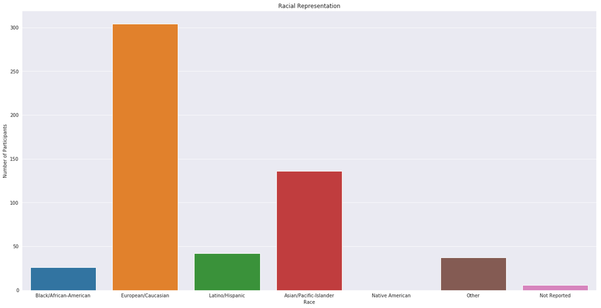

```python
figure(figsize=(22,11)) # set graph size
races = {
    1: 'Black/African-American',
    2: 'European/Caucasian',
    3: 'Latino/Hispanic',
    4: 'Asian/Pacific-Islander',
    5: 'Native American',
    6: 'Other',
    7: 'Not Reported',
}
# Initialize counters
race_counts = {1: 0, 2: 0, 3: 0, 4: 0, 5: 0, 6:0, 7: 0}

total = 0
for name, group in groups:
    val = group['race'].mean()
    if (not math.isnan(val)):
        val = int(val)
        total += 1
        race_counts[val] += 1
    else:
        race_counts[7] += 1

for key, value in race_counts.items():
    print('{:s}:  {:d}, {:3.1f}%'.format(races[key], value, (value/total) * 100))

print('Total Reported: %i' % total)
ax = sns.barplot(x=list(races.values()), y=list(race_counts.values()))
ax.set(xlabel='Race', ylabel='Number of Participants', title="Racial Representation")
plt.show()
```

This shows that race may bias our results slightly. These factors will be important to consider if we later decide to make any assumptions from our analysis.

### Looking for Trends

Now that we've analyized the demographic of our dataset, let's start trying to answer the question that we initially proposed, "what values do people look for in a partner?" Let's start by identifing which factors could potentially influence attraction. We want to look for the factors of each participant's partner and see how they rated their partner based on these factors. I expect the following to be important factors.

- samerace (Do the participants have same race/what race)
- int_corr (Correlation of the )
- attr_o (for the 6 attributes)

We will judge a participants attractiveness by the number of partners that wanted to see them again. Later we normalize this value to better understand the participants' success:

- dec_o (Decision by partner)

Now let's try to see if there is a relationship between the 6 character traits and match success. In order to see if there is a relationship, we will calculate a linear regression line for each of the 6 traits. To make things easier, we will be using sklearn's `LinearRegression()` function in order to construct our regression lines. If you are not already familiar with linear regression I recommend you learn more [here](http://www.stat.yale.edu/Courses/1997-98/101/linreg.htm) before proceeding.

We will look at each participant's average success rate to determine the 'match success'. For example, if a participant has 10 dates and 7 of their partners decide they want to match with them, then that participant's match success is 7/10 or 0.7. This normalizes our data and this helps because each event had a different number of dates.

```python
# Plots a scatter plot with a linear regression line on top. In addition, the R^2 value of each linear regression are displayed.
def corr_plot(x, y, groups, xlabel, ylabel, title="", color='blue'):
    match = groups[x].values.reshape(-1,1) # convert list of matches from 1D -> 2D array

    # plot our raw data
    ax = sns.scatterplot(x, y, data=groups, color=color)

    # Calculate a linear regression model using sci-kit learn
    regr = linear_model.LinearRegression()
    regr.fit(match, groups[y])

    # Predict our data using the linear reg. model
    pred = regr.predict(match)

    # Plot the predicted regression data (line)
    sns.lineplot(groups[x], pred, color="red")

    # Calculate R^2 value so we can judge the correlation strength
    r2 = r2_score(groups[y], pred)
    r = math.sqrt(r2)

    # Set the axis labels and title
    title = title + ' (R: %0.3f)' % (r)
    ax.set(xlabel=xlabel, ylabel=ylabel, title=title)
```

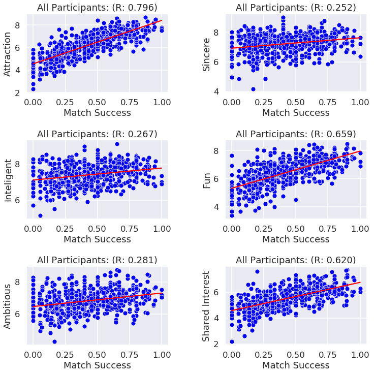

```python
# Set various display settings for our charts
figure(figsize=(12,12))
plt.subplots_adjust(hspace=.6, wspace=.4)
sns.set_context("talk")

# Each group in 'groups' is one participant.
# We calculate the mean of each participant in order to get an average over all of their dates for that day.
means = groups.mean()

# Various lists we'll use in a second...
names = ['attr_o', 'sinc_o', 'intel_o', 'fun_o', 'amb_o', 'shar_o'] # Name of columns
expanded_names = ['Attraction','Sincere', 'Inteligent', 'Fun', 'Ambitious', 'Shared Interest'] # Full names of traits/cols

# For each of our 6 traits, we want to plot the trait data vs their partner's decision to match them (match success)
for i, name in enumerate(names):
    plt.subplot(3, 2, i + 1) # break into 6 separate plots
    corr_plot('dec_o', names[i], means, 'Match Success', expanded_names[i], "All Participants:")

plt.show()
```

This reveals some telling information about what traits influenced whether a participant would want to match or not. Using an $R$ value to measure the accuracy (correlation) of our linear regression models, it's clear that Attraction, Fun, and Shared Interest are much stronger predictors of a match than Ambitious, Inteligent, and Sincere. If you're unfamiliar with $R$ values, you can read more [here](https://www.dummies.com/education/math/statistics/how-to-interpret-a-correlation-coefficient-r/). Overall it appears that physical attraction is the strongest predictor of match success.

Let's see if there is a difference between male/females when it comes to these factors. We split our previous `means` data into male and female data, then plot in the same way we did for the previous charts. The male graph has been colored blue and the female graph is colored pink for clarity. Each of the 6 attributes are shown across each row.

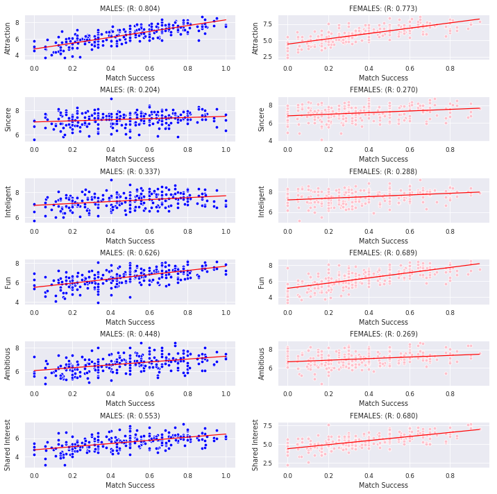

```python
# Set various display settings for our charts
figure(figsize=(12,12))
sns.set_context("paper")
plt.subplots_adjust(hspace=.8)

means_male = means[means['gender'] == 0] #only males
means_female = means[means['gender'] == 1] #only females

j = 1 # Counter for the plot number

# For each of the 6 traits, plot the male and the female plots of trait vs. match success
for i, name in enumerate(names):

    plt.subplot(6, 2, j)
    corr_plot('dec_o', names[i], means_male, 'Match Success', expanded_names[i], "MALES:")
    j += 1

    plt.subplot(6, 2, j)
    corr_plot('dec_o', names[i], means_female, 'Match Success', expanded_names[i], "FEMALES:", 'pink')
    j += 1

plt.show()
```

As before we judge the correlation of the factors based on the linear regression's $R^2$ value.

These new charts reveal interesting data about how males and females judge overall attractiveness differently. Females appear to value physical attraction slightly less than males. As expected, both genders seem to take little value in sincerity and intelligence. It appears that females value Fun slightly more than males. The most significant difference the two gender comes from their value of ambition. Males seem to value ambition in the opposite gender significantly more than females. Meanwhile, it appears that while both male and females believe shared interests are important, females believe this is more important than males.

Another way of visualizing these correlations is through the use of correlation heatmaps. These allow us to see a variety of correlations without having to manually calculate each possibility.

The first step is to create the subset of our dataset that we want to look for correlations on. For this we use the same columns we were using in the graphs. Pandas provides the `corr()` function which quickly calculates all of the correlations for a given dataset. Simply because we say interesting results before, let's continue to divide the data by gender.

```python
means_traits_male = means_male[['dec_o', 'attr_o', 'sinc_o', 'intel_o', 'fun_o', 'amb_o', 'shar_o']]
means_traits_male = means_traits_male.corr()
print('Males:')
display(means_traits_male)

means_traits_female = means_female[['dec_o', 'attr_o', 'sinc_o', 'intel_o', 'fun_o', 'amb_o', 'shar_o']]
means_traits_female = means_traits_female.corr()
print('Females:')
display(means_traits_female)
```

```
Males:
```

|  | dec_o | attr_o | sinc_o | intel_o | fun_o | amb_o | shar_o |
| --- | --- | --- | --- | --- | --- | --- | --- |
| dec_o | 1.000000 | 0.803605 | 0.203929 | 0.337258 | 0.625968 | 0.447977 | 0.553075 |
| attr_o | 0.803605 | 1.000000 | 0.266396 | 0.368816 | 0.658821 | 0.493388 | 0.600349 |
| sinc_o | 0.203929 | 0.266396 | 1.000000 | 0.646020 | 0.384740 | 0.350248 | 0.361157 |
| intel_o | 0.337258 | 0.368816 | 0.646020 | 1.000000 | 0.394567 | 0.635688 | 0.490269 |
| fun_o | 0.625968 | 0.658821 | 0.384740 | 0.394567 | 1.000000 | 0.563761 | 0.703630 |
| amb_o | 0.447977 | 0.493388 | 0.350248 | 0.635688 | 0.563761 | 1.000000 | 0.594051 |
| shar_o | 0.553075 | 0.600349 | 0.361157 | 0.490269 | 0.703630 | 0.594051 | 1.000000 |

```
Females:
```

|  | dec_o | attr_o | sinc_o | intel_o | fun_o | amb_o | shar_o |
| --- | --- | --- | --- | --- | --- | --- | --- |
| dec_o | 1.000000 | 0.773089 | 0.269977 | 0.288326 | 0.689445 | 0.269381 | 0.680164 |
| attr_o | 0.773089 | 1.000000 | 0.304579 | 0.272708 | 0.715588 | 0.313214 | 0.670674 |
| sinc_o | 0.269977 | 0.304579 | 1.000000 | 0.682964 | 0.374728 | 0.407601 | 0.403616 |
| intel_o | 0.288326 | 0.272708 | 0.682964 | 1.000000 | 0.371883 | 0.648587 | 0.438380 |
| fun_o | 0.689445 | 0.715588 | 0.374728 | 0.371883 | 1.000000 | 0.455820 | 0.785026 |
| amb_o | 0.269381 | 0.313214 | 0.407601 | 0.648587 | 0.455820 | 1.000000 | 0.412552 |
| shar_o | 0.680164 | 0.670674 | 0.403616 | 0.438380 | 0.785026 | 0.412552 | 1.000000 |

While this dataset contains lots of incredibly useful information, it's not exactly easy to interpret at a glance. To solve this issue we will create heatmaps using Seaborn to visually display the correlation data.

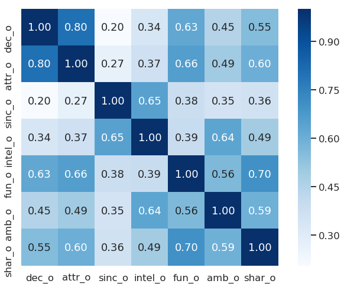

```python
# Seaborn settings
plt.figure(figsize=(12,8))
sns.set_context("talk")

# Heatmap of factors for Men
sns.heatmap(data=means_traits_male, cmap='Blues', fmt='0.2f', square=True, annot=True)
plt.show()
```

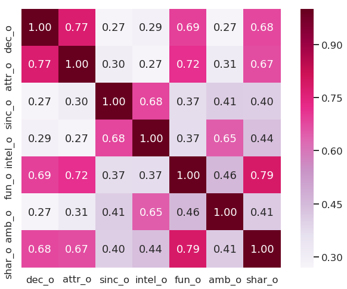

```python
# Seaborn settings
plt.figure(figsize=(12,8))
sns.set_context("talk")

# Heatmap of factors for Women
sns.heatmap(data=means_traits_female, cmap="PuRd", fmt='0.2f', square=True, annot=True)
plt.show()
```

For the purpose of data exploration these heatmaps can be incredibly helpful at finding what factors are the most influential of other factors. Because we already created linear regression plots before, these heatmaps are simply reiterating the same things we knew before, however it's important to know that there are mulitple ways of finding the most important factors in a dataset.

So far we have only looked at the 6 characters traits and related them to match success but there were a few other factors we guessed may affect match success. Those two factors were the two partners having the same race and the correlation between their interests (all participants were surveyed about their interests). Let's create another heatmap for just these factors to see if they influence match success.

```python
# Create correlation dataframe
other_facts = df[['dec_o', 'samerace', 'int_corr']]
other_facts = other_facts.corr()
other_facts
```

|  | dec_o | samerace | int_corr |
| --- | --- | --- | --- |
| dec_o | 1.000000 | 0.023626 | 0.018824 |
| samerace | 0.023626 | 1.000000 | 0.025031 |
| int_corr | 0.018824 | 0.025031 | 1.000000 |

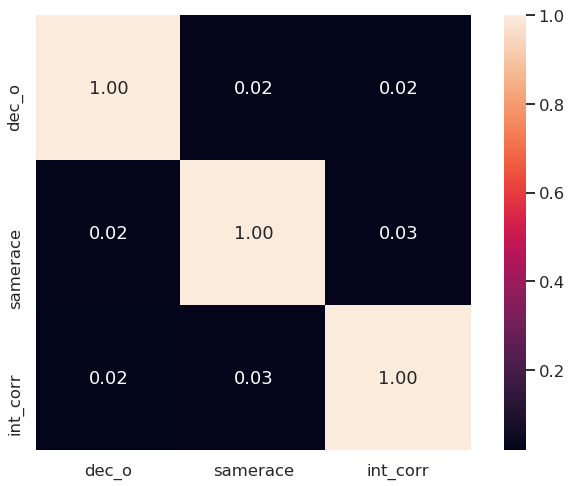

```python
# Seaborn settings
plt.figure(figsize=(12,8))
sns.set_context("talk")

# Heatmap of samerace, int_corr, and dec_O
sns.heatmap(data=other_facts, fmt='0.2f', square=True, annot=True)
plt.show()
```

This heatmap clearly shows that having the same race and having similar interests (according to their survey results) have little impact on match success, so we can rule these out as potential factors.

## Data Modeling

Now that we've discovered the most important factors, let's see if we can use this knowledge to create a model to predict someone's match success based on their character traits. In order to create this prediction model we will use something called multiple linear regression. Later on, we will use a more advanced machine learning algorithm to create the same model. We will compare our model to the ML model to gauge the accuracy of our model.

Multiple Linear Regression follows the same principle as Single Linear Regression (as done earlier) with the difference being that there are mulitple inputs. For our model we will have 6 inputs, one for each of the 6 attributes we discussed earlier. The mathematics behind it extend the depth of this tutorial, but if you're interested you can learn more [here](http://www.stat.yale.edu/Courses/1997-98/101/linmult.htm). We will complete a model for both men and women.

When testing out our models, we are going to use a procedure known as [10-Fold Crossvalidation](https://www.openml.org/a/estimation-procedures/1). This procedure involves training and scoring 10 models using 10 different training/testing sets. Then the mean accuracy of all of the tests is recorded as the final score. This tests aims to remove the variablity in scores due to different train/test data.

```python
# Split our data into our x, y inputs
x = df[['attr_o', 'sinc_o', 'intel_o', 'fun_o', 'amb_o', 'shar_o']].values
y = df[['dec_o']].values

# Split the data into 10 folds to test on.
kf = KFold(n_splits=10, shuffle=True)

q = 0 # iterator
scores = np.zeros([10]) # Array for storing scores

# For each of the 10 folds do the following...
# Train: the training data
# Test: the test data
for train, test in kf.split(x):
    # Create our model and fit using our training data
    regr = linear_model.LinearRegression()
    regr.fit(x[train], y[train])

    # Score using R^2
    scores[q] = regr.score(x[test], y[test])
    q += 1

print("Coef: %s" % regr.coef_)

gd_score = (scores.mean(), scores.std() * 2, math.sqrt(scores.mean()))
print("R^2: %0.4f (+/- %0.4f), R: %0.4f" % gd_score)
```

```
Coef: [[ 0.09214486 -0.01380724  0.00381769  0.0405509  -0.02096836  0.04053392]]
R^2: 0.2753 (+/- 0.0271), R: 0.5247
```

Our mulitple linear regression model has an $R$ value of about 0.52 which means that our model fits the data but the correlation is not very strong. This value is fairly good considering we are trying to predict human behavior, which is inherently eratic.

It's also interesting to notice the coefficients our linear model. Notice that the 1st, 4th, and 6th coefficients are much larger than the other coefficients. This is because these represent the same 3 factors that we noticed had a strong correlation before (Physical Attraction, Fun, and Shared Interests).

The best way to judge whether our model is good or bad is to compare it to another ML algorithm's performance and see how they score against eachother. Let's compare our linear model to the k-Nearest Neighbors algorithm. We also use a 10-fold Cross validation test for this algorithm so the comparison is fair.

```python
y = y.ravel() # Convert from column vector to 1D vector

# Split the data into 10 folds to test on.
kf = KFold(n_splits=10, shuffle=True)

q = 0 # iterator
scores = np.zeros([10]) # Array for storing scores

# For each of the 10 folds do the following...
# Train: the training data
# Test: the test data
for train, test in kf.split(x):
    # Create kNN model and fit using our training data
    neigh = KNeighborsClassifier(n_neighbors=6, weights='distance')
    neigh.fit(x[train],y[train])

    # Score using R^2
    scores[q] = neigh.score(x[test],y[test])
    q += 1

gd_score = (scores.mean(), scores.std() * 2, math.sqrt(scores.mean()))
print("R^2: %0.4f (+/- %0.4f), R: %0.4f" % gd_score)
```

```
R^2: 0.7095 (+/- 0.0231), R: 0.8423
```

#### Why is this important?

These models are incredibly important to data science as they illustrate the fundamental ideas of machine learning. The models allow us to predict someone's match success based only on people's review of them.

### Summary

The purpose of this analysis was to introduce many of the key elements of data science. Our goal was to discover what factors of a person would lead to a match. We did this by analyzing the relationship between certain perceived factors of a person and whether or not a partner would match with them.

We found that overall physical attractiveness, fun, and shared interests were the most important personality traits for a person, meaning that high values in these categories would often lead to a match. Meanwhile sincerity, inteligence, and ambition had little affect on whether or not a partner would match. Then we split the data by gender and looked for differences in how much each gender valued the factors. The significant results of this testing was that men value ambition more than women while women value shared interests more than men.

Then we created heatmaps to graphically display the correlation between the factors and match success.

Finally, we created models using Machine Learning to be able to predict a person's match success based on their perceived traits.